# R Session Population Genetics

Install the following packages.

For the sequence data manipulation and missingness plotting: seqinr gplots RColorBrewer

For the population structure visualisation in pophelper: Cairo ggplot2 gridExtra gtable tidyr devtools

For the population genetics statistics: adegenet pegas

```r
library(adegenet)
library(adegenet)
library(pegas)
```

FILE FORMATS FASTA seqinr With the package seqinr you can read in a fasta file. Below you see an example where I used a aligned fasta file, checked whether the triplicated samples (library in triplicate, treated as separate samples during assembly) had differences in their sequence between replicates of individuals, or whether differences could be attritbuted to missing data.

```r
All_diff<-c(Diff_worry['1572_A','1572_B'], Diff_worry['1572_B','1572_C'],Diff_worry['1572_A','1572_C'],
  Diff_worry['1573_A','1573_B'], Diff_worry['1573_B','1573_C'],Diff_worry['1573_A','1573_C'],
  Diff_worry['1574_A','1574_B'], Diff_worry['1574_B','1574_C'],Diff_worry['1574_A','1574_C'],
  Diff_worry['4112_A','4112_B'], Diff_worry['4112_B','4112_C'],Diff_worry['4112_A','4112_C'],
  Diff_worry['4113_A','4113_B'], Diff_worry['4113_B','4113_C'],Diff_worry['4113_A','4113_C'],
  Diff_worry['4114_A','4114_B'], Diff_worry['4114_B','4114_C'],Diff_worry['4114_A','4114_C']
  )
All_diff<-c(Diff_worry['1572_A','1572_B'], Diff_worry['1572_B','1572_C'],Diff_worry['1572_A','1572_C'],
  Diff_worry['1573_A','1573_B'], Diff_worry['1573_B','1573_C'],Diff_worry['1573_A','1573_C'],
  Diff_worry['1574_A','1574_B'], Diff_worry['1574_B','1574_C'],Diff_worry['1574_A','1574_C'],
  Diff_worry['4112_A','4112_B'], Diff_worry['4112_B','4112_C'],Diff_worry['4112_A','4112_C'],
  Diff_worry['4113_A','4113_B'], Diff_worry['4113_B','4113_C'],Diff_worry['4113_A','4113_C'],
  Diff_worry['4114_A','4114_B'], Diff_worry['4114_B','4114_C'],Diff_worry['4114_A','4114_C']
  )
mean(All_diff)
```

```
[1] 0.004901468
```

Good, we can see that only a very small portion (<1%) of the differences between the replicates of individuals is due to an actually different nucleotide.

Now I want to visualise this with a heatmap. ##THIS DOESN’T EXECUTE WELL IN MARKDOWN

```
numeric(0)
```

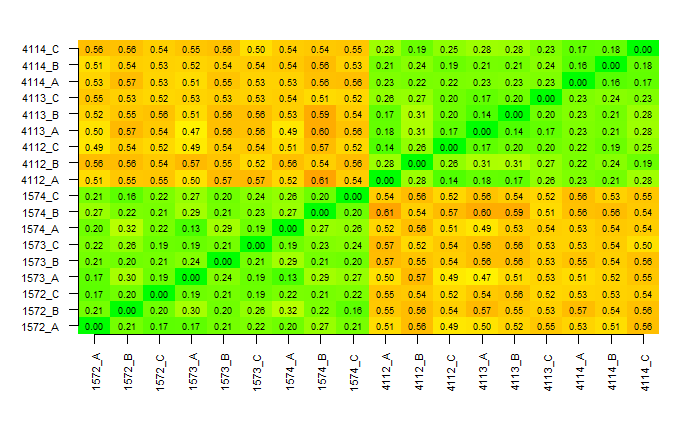

```r
image(1:dim, 1:dim1, Out_Perc_no_worries, axes = FALSE, xlab="", ylab="", col=my_palette, breaks=col_breaks)+
  axis(1, 1:dim1, colnames(Out_Perc_no_worries), cex.axis = 0.7, las=3)+
  axis(2, 1:dim1, colnames(Out_Perc_no_worries), cex.axis = 0.7, las=1)+
  text(expand.grid(1:dim1, 1:dim1), sprintf("%0.2f", Out_Perc_no_worries), cex=0.54)
```

Why do we observe the two square blocks in the table?

Now we also want to see this figure for the “really concerning” differences between the sequences

```
numeric(0)
```

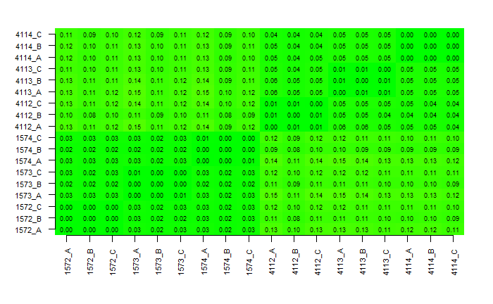

```r
image(1:dim2, 1:dim2, Diff_worry, axes = FALSE, xlab="", ylab="", col=my_palette, breaks=col_breaks)+
  axis(1, 1:dim2, colnames(Diff_worry), cex.axis = 0.7, las=3)+
  axis(2, 1:dim2, colnames(Diff_worry), cex.axis = 0.7, las=1)+
  text(expand.grid(1:dim2, 1:dim2), sprintf("%0.2f", Diff_worry), cex=0.54)
```

VCF vcfR To read in and manipulate a vcf file, one can use the R package vcfR: https://cran.r-project.org/web/packages/vcfR/vignettes/intro_to_vcfR.html

BAM/SAM scanBam To import, count, index, filter, sort, and merge BAM files: https://rdrr.io/bioc/Rsamtools/man/scanBam.html

```
Rsamtools
To read in and manipulate a BAM/SAM file, one can use the R package Rsamtools:
https://kasperdanielhansen.github.io/genbioconductor/html/Rsamtools.html
```

Data filtering It is nice to be able to filter your data manually. This allows you to understand better what you are working with. Examples of SNPs that you might want to filter out are singletons. Or you might want to work with only the di-allelic SNPs in your dataset, because many softwares only utilise di-allelic SNPs. In my case, I wanted to see which SNPs were present as one variant in one of my species, and as another in another species. With these SNPs I would be able to analyse the hybrids between both species. In the next code, I filtered my data for such ‘species specific’ SNPs based on my assumed ‘pure’ populations.

## NOTE: add a map at this point for checking the populations?

```r
Tot_not_diagnostic+Tot_diagnostic
```

```
[1] 581
```

Questions: How many diagnostic markers do I have? How many non-diagnostic markers do I have? Does it add up to the total of markers in the input file? Where did the other markers go?

Challenge: write a code that takes one SNP per RAD locus randomly

STRUCTURE Run structure-like analysis in R (includes some nice mapping options): http://membres-timc.imag.fr/Olivier.Francois/tutoRstructure.pdf And: https://onlinelibrary-wiley-com.naturalis.idm.oclc.org/doi/pdf/10.1111/1755-0998.12559 Or: https://github.com/Tom-Jenkins/admixture_pie_chart_map_tutorial/blob/master/pie_chart_admixture_map_tutorial.R

Visualisation with Pophelper ###THIS DOESN’T WORK ANYMORE!

```r
plotQ(qlist=c(Q2[1], Q1[1]), imgoutput='join', clustercol=c("blue", "red"), grplab=Pop_label, grplabsize = 1, showlegend=T, divtype= 1, legendlab=c("Bufo bufo","Bufo spinosus"), splab=c("mtDNA", "Structure"), linecol="white", pointtype=NA, grplabpos=1, imgtype="tiff")
```

```
is.qlist: Attribute 'ind' is missing in one or more runs. Run as.qlist().
is.qlist: Attribute 'k' is missing in one or more runs. Run as.qlist().
is.qlist: Attribute 'ind' is missing in one or more runs. Run as.qlist().
is.qlist: Attribute 'k' is missing in one or more runs. Run as.qlist().
Removed 21 rows containing missing values (geom_point).
```

```
Drawing plot ...
Joined2Files-20200330144141.tiff exported.
```

Look at the many options available for your population structure plotting in R with the PopHelper package here: http://www.royfrancis.com/pophelper/articles/index.html#plotq

## Population genetic analyses in Adegenet

Adegenet Read in the data & replace missing data with the mean frequency (there are other methods available). Other file formats are possible, but here we use a structure file.

```r
levels(obj1$pop)
```

```
 [1] "T1_16" "T1_13" "T1_12" "T1_11" "T1_10" "T1_8"  "T1_14" "T1_1"  "T1_2"  "T1_5"  "T1_3"
[12] "T1_6"  "T1_9"  "T1_20" "T1_19" "T1_21" "T1_22" "T1_18" "T1_4"  "T1_7"  "T1_15" "T2_17"
[23] "T2_16" "T2_6"  "T2_12" "T2_11" "T2_10" "T2_8"  "T2_7"  "T2_9"  "T2_13" "T2_14" "T2_15"
```

LD

```r
LD2(obj1, details = FALSE)
```

```
Error in matrix(NA_integer_, n, p) : non-numeric matrix extent
```

HW

```r
Test_pop_T1_11
```

```
             chi^2 df Pr(chi^2 >)
L0001           NA NA          NA
L0002  0.000000000  0  1.00000000
L0003  0.000000000  0  1.00000000
L0004  0.000000000  0  1.00000000
L0005  0.000000000  0  1.00000000
L0006  0.000000000  0  1.00000000
L0007  0.007747934  1  0.92985891
L0008  0.000000000  0  1.00000000
L0009  0.000000000  0  1.00000000
L0010  0.000000000  0  1.00000000
L0011  4.000000000  1  0.04550026
L0012           NA NA          NA
L0013  0.000000000  0  1.00000000
L0014  0.000000000  0  1.00000000
L0015  0.000000000  0  1.00000000
L0016           NA NA          NA
L0017  0.000000000  0  1.00000000
L0018  2.000000000  1  0.15729921
L0019  0.000000000  0  1.00000000
L0020  0.000000000  0  1.00000000
L0021  0.000000000  0  1.00000000
L0022  0.000000000  0  1.00000000
L0023  0.703379501  1  0.40165046
L0024 10.000000000  3  0.01856614
L0025  0.027700831  1  0.86781411
L0026  0.163265306  1  0.68616785
L0027  0.000000000  0  1.00000000
L0028  0.000000000  0  1.00000000
L0029  0.000000000  0  1.00000000
L0030  0.000000000  0  1.00000000
L0031  0.000000000  0  1.00000000
L0032  0.000000000  0  1.00000000
L0033  0.000000000  0  1.00000000
L0034  0.000000000  0  1.00000000
L0035  1.548186974  1  0.21340329
L0036           NA NA          NA
L0037  0.000000000  0  1.00000000
L0038           NA NA          NA
L0039           NA NA          NA
L0040  0.027700831  1  0.86781411
L0041  2.000000000  1  0.15729921
L0042  0.000000000  0  1.00000000
L0043           NA NA          NA
```

Questions: Why do we have rows with no output? Why do we have only 43 loci?

PCA Perform a pca

[output not shown]

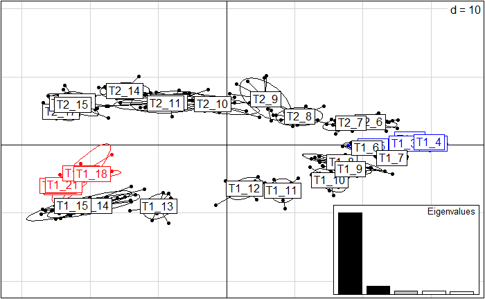

```r
s.class(pca1$li, pop(obj1), axesel=FALSE, cstar=1, cpoint=1, col=c(rep("black", 7),
                                                                   rep("blue", 4),
                                                                   rep("black", 2),
                                                                   rep("red", 5), "blue",
                                                                   "black", "black",
                                                                   rep("black", 12))) +
  add.scatter.eig(pca1$eig[1:5],3,1,2, ratio=.3, posi="bottomright")
```

This looks good.

What is the variance explained per axis?

```r
summary(pca1)
```

```
Class: pca dudi
Call: dudi.pca(df = NA_mean, scale = F, scannf = F, nf = 3)

Total inertia: 1244

Eigenvalues:
    Ax1     Ax2     Ax3     Ax4     Ax5
 334.01   34.58   16.21   14.51   12.98

Projected inertia (%):
    Ax1     Ax2     Ax3     Ax4     Ax5
 26.841   2.779   1.302   1.166   1.043

Cumulative projected inertia (%):
    Ax1   Ax1:2   Ax1:3   Ax1:4   Ax1:5
  26.84   29.62   30.92   32.09   33.13

(Only 5 dimensions (out of 372) are shown)
```

DAPC & Compoplot With adegenet: http://adegenet.r-forge.r-project.org/files/tutorial-dapc.pdf